# ChromHMM: robustness check

SK

30.01.2020

# Consensus peak datasets

Thusfar we used the *consensus* peaks from different biological replicates of six marks from two cell populations (PC and HC) to discover epigenetic patterns with ChromHMM. The concensus peaks were constructed based on 3 replicates (per mark) in PC and 2 replicates (per mark) in HC. Based on this data we fitted a 15-state ChromHMM model (M0).

To test the robustness of M0, we created 3 sets of conensus datasets (P1-P3) from different permutations of 2 replicates in PC. The HC consensus datasets remained unaltered. Next, we fitted three 15-state ChromHMM models (M1-M3) based on each dataset, and compared the results (emmission probabilities) between the different models including M0 (based on P0 dataset).

## P0

```
FALSE  [1] "PC-H3K27ac-S3-S5-S8-Intersect-ID35-ID39-ID47.bed"
FALSE  [2] "PC-H3K27me3-S2-S6-S8-Intersect-ID29-ID62-ID80.bed"
FALSE  [3] "PC-H3K36me3-S4-S5-S6-Intersect-ID37-ID40-ID42.bed"
FALSE  [4] "PC-H3K4me3-S1-S2-S7-Intersect-ID26-ID30-ID45.bed"
FALSE  [5] "PC-H3K9ac-S1-S2-S3-Intersect-ID27-ID31-ID36.bed"
FALSE  [6] "PC-H3K9me3-S2-S3-S6-Intersect-ID32-ID34-ID43.bed"
FALSE  [7] "HC-H3K27ac-S5-S7-Intersect-ID19-ID25.bed"
FALSE  [8] "HC-H3K27me3-S2-S3-Intersect-ID14-ID16.bed"
FALSE  [9] "HC-H3K36me3-S5-S7-Intersect-ID20-ID24.bed"
FALSE [10] "HC-H3K4me3-S2-S5-Intersect-ID15-ID21.bed"
FALSE [11] "HC-H3K9ac-S2-S3-Intersect-ID12-ID17.bed"
FALSE [12] "HC-H3K9me3-S2-S5-Intersect-ID13-ID22.bed"
```

## P1

```
FALSE  [1] "Col2H3K27ac_Intersect_S3-S5.bed"
FALSE  [2] "Col2H3K27me3_Intersect_S2-S6.bed"
FALSE  [3] "Col2H3K36me3_Intersect_S4-S5.bed"
FALSE  [4] "Col2H3K4me3_Intersect_S1-S2.bed"
FALSE  [5] "Col2H3K9ac_Intersect_S1-S2.bed"
FALSE  [6] "Col2H3K9me3_Intersect_S2-S3.bed"
FALSE  [7] "HC-H3K27ac-S5-S7-Intersect-ID19-ID25.bed"
FALSE  [8] "HC-H3K27me3-S2-S3-Intersect-ID14-ID16.bed"
FALSE  [9] "HC-H3K36me3-S5-S7-Intersect-ID20-ID24.bed"
FALSE [10] "HC-H3K4me3-S2-S5-Intersect-ID15-ID21.bed"
FALSE [11] "HC-H3K9ac-S2-S3-Intersect-ID12-ID17.bed"
FALSE [12] "HC-H3K9me3-S2-S5-Intersect-ID13-ID22.bed"
```

## P2

```
FALSE  [1] "Col2H3K27ac_Intersect_S3-S8.bed"
FALSE  [2] "Col2H3K27me3_Intersect_S2-S8.bed"
FALSE  [3] "Col2H3K36me3_Intersect_S4-S6.bed"
FALSE  [4] "Col2H3K4me3_Intersect_S1-S7.bed"
FALSE  [5] "Col2H3K9ac_Intersect_S1-S3.bed"
FALSE  [6] "Col2H3K9me3_Intersect_S2-S6.bed"
FALSE  [7] "HC-H3K27ac-S5-S7-Intersect-ID19-ID25.bed"
FALSE  [8] "HC-H3K27me3-S2-S3-Intersect-ID14-ID16.bed"
FALSE  [9] "HC-H3K36me3-S5-S7-Intersect-ID20-ID24.bed"
FALSE [10] "HC-H3K4me3-S2-S5-Intersect-ID15-ID21.bed"
FALSE [11] "HC-H3K9ac-S2-S3-Intersect-ID12-ID17.bed"
FALSE [12] "HC-H3K9me3-S2-S5-Intersect-ID13-ID22.bed"
```

## P3

```
FALSE  [1] "Col2H3K27ac_Intersect_S5-S8.bed"
FALSE  [2] "Col2H3K27me3_Intersect_S6-S8.bed"
FALSE  [3] "Col2H3K36me3_Intersect_S5-S6.bed"
FALSE  [4] "Col2H3K4me3_Intersect_S2-S7.bed"
FALSE  [5] "Col2H3K9ac_Intersect_S2-S3.bed"
FALSE  [6] "Col2H3K9me3_Intersect_S3-S6.bed"
FALSE  [7] "HC-H3K27ac-S5-S7-Intersect-ID19-ID25.bed"
FALSE  [8] "HC-H3K27me3-S2-S3-Intersect-ID14-ID16.bed"
FALSE  [9] "HC-H3K36me3-S5-S7-Intersect-ID20-ID24.bed"
FALSE [10] "HC-H3K4me3-S2-S5-Intersect-ID15-ID21.bed"
FALSE [11] "HC-H3K9ac-S2-S3-Intersect-ID12-ID17.bed"
FALSE [12] "HC-H3K9me3-S2-S5-Intersect-ID13-ID22.bed"
```

# Comparison of consensus peaks numbers and coverages

## How many consensus peaks are there in PC and HC for different mark?

- x2 = consensus based on replicates
- x3 = consensus based on triplicates

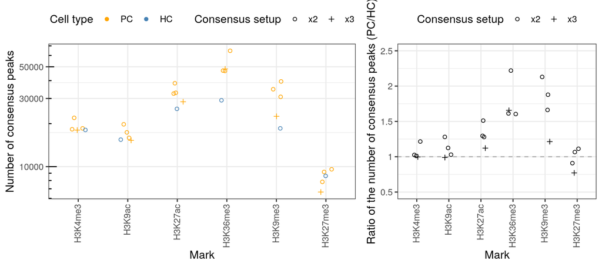

## Similar story across different chromosomes?

- x2 = consensus based on replicates
- x3 = consensus based on triplicates
- For number of peaks = 0 the symbol would not be shown (e.g. chr Y)

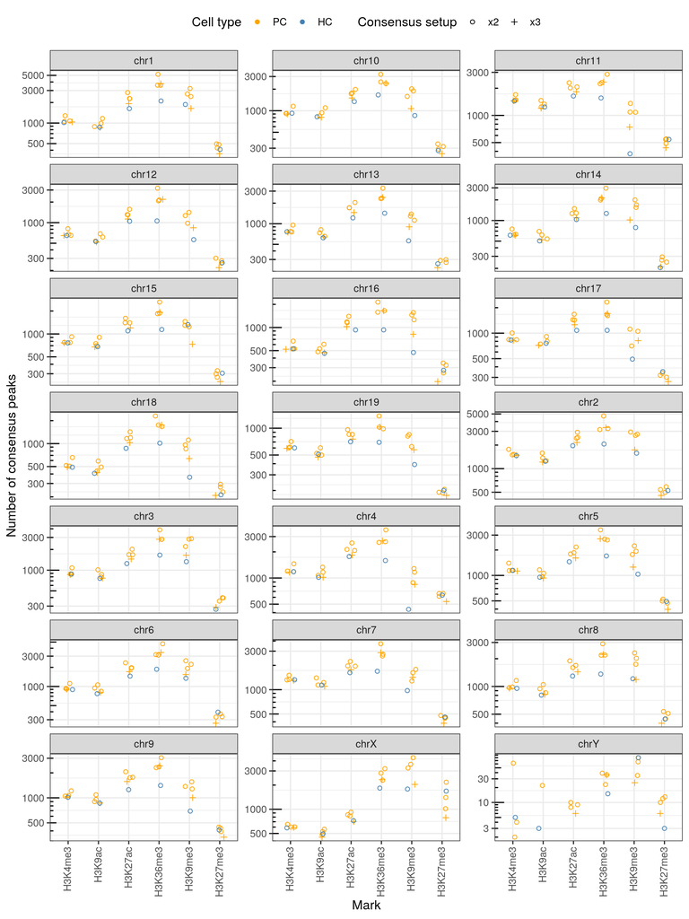

## What is the peak coverage (in Mbs) in PC and HC for different marks?

- x2 = consensus based on replicates
- x3 = consensus based on triplicates

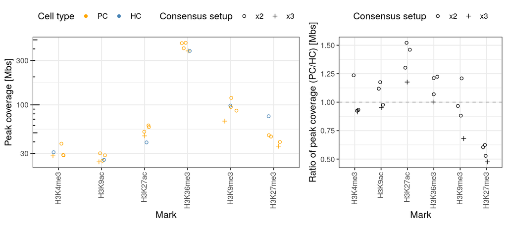

## Similar picture across chromosomes?

- x2 = consensus based on replicates
- x3 = consensus based on triplicates
- For coverage = 0 the symbol would not be shown (e.g. chr Y)
- **Important: Look at coverage of H3K27me3 in chromosome X**

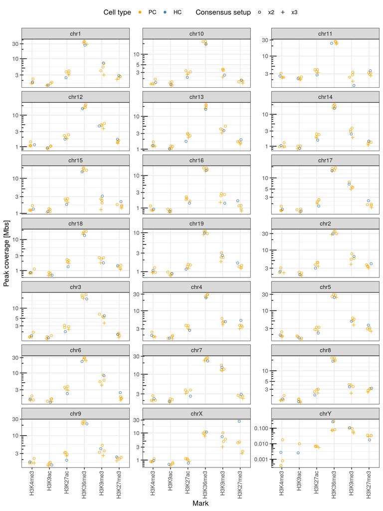

# Comparison of ChromHMM results

Ideally, we would expect each branch in the hierarchical tree to contain four leaves (one from each model). For most states this is the case.

```
FALSE png
FALSE   2
```

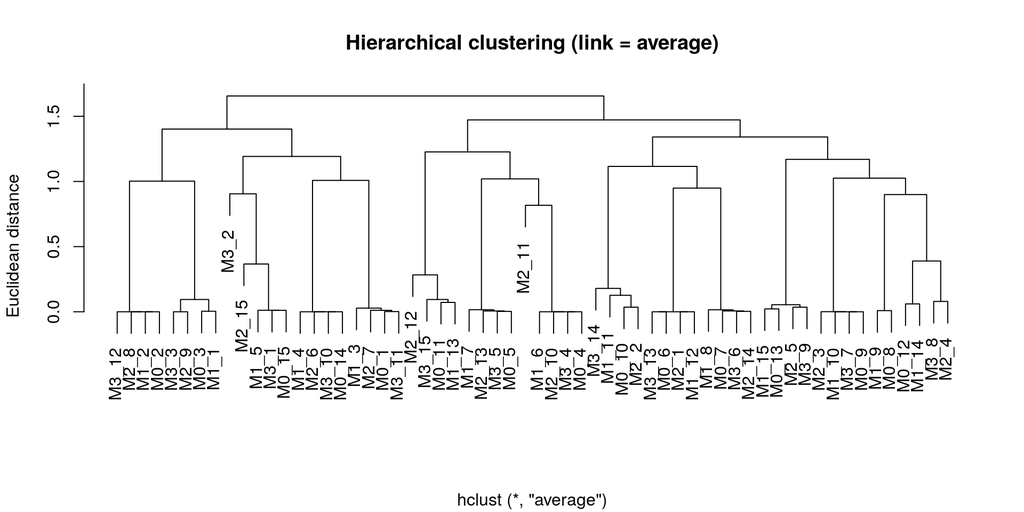

## Emissions diagrams

- state cluster is cluster of 4 ChromHMM states obtained from the cluster dendrogram
- hint: outlying states were merged together (difference is expected)
- state (dark red text) is state ID set by ChromHMM

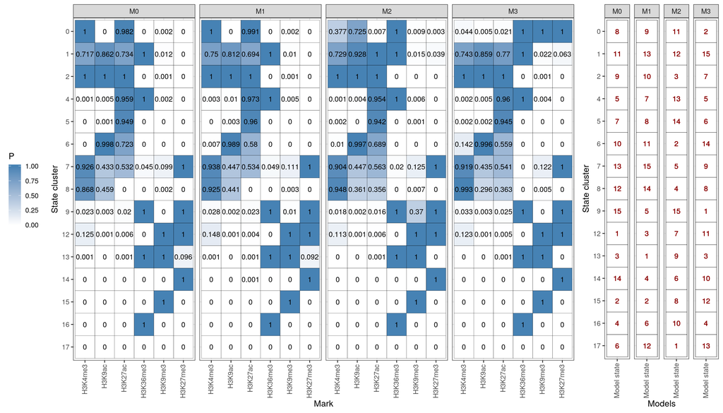

## Comparison of the frequency of bins having different ChromHMM states

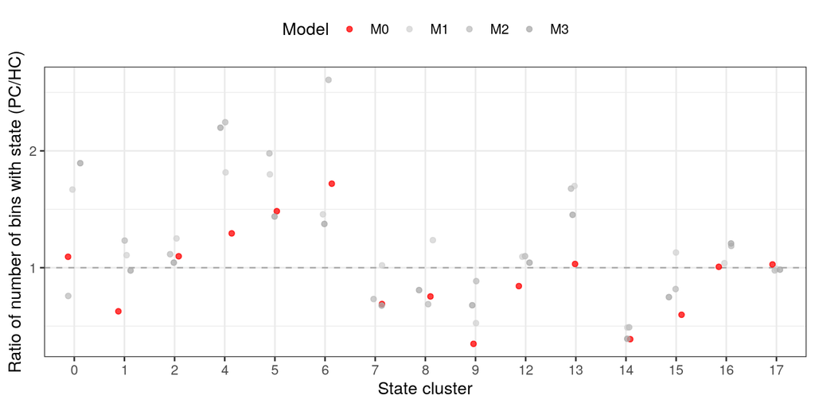

## Table with frequency of bins with different ChromHMM states

- first number = %
- number in paranthesis = count of bins / 1000
- column named state (dark red text) indicates the state ID set by ChromHMM

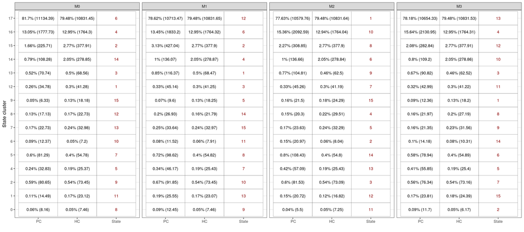

## Sanity check [for me]

- coverage delta should be 0 if all peaks match ChromHMM bins

```
FALSE        mark cell.type model peak.coverage bin.coverage coverage.delta
FALSE 1   H3K27ac        HC     0      39447200     39447200              0
FALSE 2   H3K27ac        PC     0      46409400     46409400              0
FALSE 3   H3K27ac        PC     1      57623800     57623800              0
FALSE 4   H3K27ac        PC     2      60013200     60013200              0
FALSE 5   H3K27ac        PC     3      51380600     51380600              0
FALSE 6  H3K27me3        HC     0      75459200     75459200              0
FALSE 7  H3K27me3        PC     0      35906400     35906400              0
FALSE 8  H3K27me3        PC     1      47116000     47116000              0
FALSE 9  H3K27me3        PC     2      45578400     45578400              0
FALSE 10 H3K27me3        PC     3      39876800     39876800              0
FALSE 11 H3K36me3        HC     0     380200000    380200000              0
FALSE 12 H3K36me3        PC     0     380629600    380629600              0
FALSE 13 H3K36me3        PC     1     406529600    406529600              0
FALSE 14 H3K36me3        PC     2     460528800    460528800              0
FALSE 15 H3K36me3        PC     3     465094400    465094400              0
FALSE 16  H3K4me3        HC     0      30925400     30925400              0
FALSE 17  H3K4me3        PC     0      28273400     28273400              0
FALSE 18  H3K4me3        PC     1      38222600     38222600              0
FALSE 19  H3K4me3        PC     2      28602200     28602200              0
FALSE 20  H3K4me3        PC     3      28861000     28861000              0
FALSE 21   H3K9ac        HC     0      25598600     25598600              0
FALSE 22   H3K9ac        PC     0      24365800     24365800              0
FALSE 23   H3K9ac        PC     1      30090600     30090600              0
FALSE 24   H3K9ac        PC     2      28628800     28628800              0
FALSE 25   H3K9ac        PC     3      25025800     25025800              0
FALSE 26  H3K9me3        HC     0      98219200     98219200              0
FALSE 27  H3K9me3        PC     0      66812000     66812000              0
FALSE 28  H3K9me3        PC     1     118740800    118740800              0
FALSE 29  H3K9me3        PC     2      94944800     94944800              0
FALSE 30  H3K9me3        PC     3      86613600     86613600              0
```